# Inleiding Statistiek

Bennett Kleinberg

Week 12

## Week 12

Associaties tussen 2 variabelen

- Deel 1: Associaties tussen categorische variabelen
- Deel 2: De Chi-kwadraattoets voor verbanden tussen variabelen
- Deel 3: Effectmaten voor de Chi-kwadraattoets

Deel 1: Associaties tussen categorische variabelen

## Tot nu toe

- gemiddelden vergelijkingstoetsen
- verbanden tussen numerieke variabelen (correlatie)

Maar (heel) vaak zijn de gegevens niet *numeriek*.

Dit is een probleem voor onze statistische toetsen!

## Niet-numerieke data

Maar we hebben veel scenario’s waar *categorische data* terugkomen:

- *ziekte vs geen ziekte* en *roken vs niet roken*
- *gehackt vs niet gehackt* en *antivirussoftware vs geen antivirussoftware*
- *extra lessen vs geen extra lessen* en *1e poging geslaagd vs 1e poging mislukt*

Discrete gegevens zijn heel gebruikelijk.

## 2-bij-2 tabellen

Al deze data kunnen in tabellen worden uitgedrukt:

|  | Pass | Fail |
| --- | --- | --- |
| Extra lessons | *A* | *B* |
| No extra lessons | *C* | *D* |

## Voorbeeld data

|  | Pass | Fail |
| --- | --- | --- |
| Extra lessons | 30 | 15 |
| No extra lessons | 40 | 15 |

## Wat nu?

- de data zijn niet ons standaard *numerieke data* geval
- onze tot nu toe geleerde tests (z-test, t-tests, correlatie) werken hier niet
- maar we hebben nog steeds vragen te stellen…

Maakt het uit of studenten extra lessen volgden?

Slaagden studenten met extra lessen vaker voor het examen dan studenten zonder extra lessen?

*Is er een verband tussen de factor **extra lessen (ja-nee)** en **resultaat (geslaagd-gezakt)?***

## Hoe te beginnen?

We kunnen kijken naar de *marges* (de sommen van rijen en kolommen)

## De tabel marges

|  | Pass | Fail | Sum |
| --- | --- | --- | --- |
| Extra lessons | 30 | 15 | 45 |
| No extra lessons | 40 | 15 | 55 |
| Sum | 70 | 30 | 100 |

## De tabel marges

- een totaal van $n=100$ studenten
- 70/100 (70%) geslaagd
- 30/100 (30%) gezakt
- 45/100 (45%) hebben extra lessen gevolgd
- 55/100 (55%) hebben geen extra lessen gevolgd

*Maar dit zegt ons (nog) niets over de associatie.*

## Inzoomen

- 30 studenten van degenen die slaagden (totaal: 70) volgden extra lessen: $P(extra lessen | geslaagd) = \frac{30}{70} = 0.43$
- 30 studenten van degenen die extra lessen volgden (totaal: 45) zijn geslaagd: $P(geslaagd |extra lessen) = \frac{30}{45} = 0.67$
- enz.

Dit maakt het snel ingewikkeld.

Er is een eenvoudiger manier: de Chi-kwadraat toets (geschreven als $\chi^2$-test)

## Assumpties

- we hebben te maken met frequenties (geen percentages)
- de niveaus (levels) van de variabelen sluiten elkaar uit (zie het als *óf … óf*)
- elke deelnemer kan slechts tot één cel in de tabel behoren
- de verwachte waarde in elke cel moet ten minste 5 zijn

*Hoe berekenen we het?*

Deel 2: De Chi-kwadraattoets voor verbanden tussen variabelen

## Onze data

|  | Pass | Fail | Sum |
| --- | --- | --- | --- |
| Extra lessons | 30 | 15 | 45 |
| No extra lessons | 40 | 15 | 55 |
| Sum | 70 | 30 | 100 |

## Doel

- we willen testen of de twee variabelen (bijlessen en examenresultaat) met elkaar geassocieerd zijn
- omgekeerd: we willen testen of ze onafhankelijk zijn

**Onafhankelijkheid van variabelen**: er is geen verband tussen variabele 1 en variabele 2 (de frequentieverdeling van variabele 1 hangt niet af van variabele 2), en omgekeerd.

## Algemene logica van de test

- we berekenen wat we zouden verwachten *als er geen verband zou zijn* tussen de variabelen
- en vergelijken dit met wat we *echt zien in de gegevens*

d.w.z. we meten hoeveel de **geobserveerde waarden** afwijken van de **verwachte waarden**.

## Hypothese van de test

Pseudohypothese:

$H_0:$ er is geen verband tussen de twee variabelen

Als we de $H_0$ verwerpen, kunnen we concluderen dat er een associatie is.

## Terug naar de test

We willen meten hoeveel de **geobserveerde waarden** afwijken van de **verwachtte waarden**

Dit doen we met de Chi-kwadraat toets.

## De $\chi^2$ test

Ingrediënten:

- Waargenomen waarden $O$
- Verwachte waarden (als er geen verband zou zijn) $E$
- rijen: $i$
- kolommen: $j$

## Berekening van $\chi^2$

Stap 1: waargenomen waarden

|  | Pass | Fail | Sum |
| --- | --- | --- | --- |
| Extra lessons | 30 | 15 | 45 |
| No extra lessons | 40 | 15 | 55 |
| Sum | 70 | 30 | 100 |

## Berekening van $\chi^2$

Stap 2: verwachte waarden

Deze zijn afhankelijk van de twee variabelen (d.w.z. een combinatie van extra lessen en examenresultaat)

Algemene formule:

$E_{i,j} = \frac{total_i * total_j}{total}$ (te lezen als: verwachte waarde in rij $i$ en kolom $j$)

In het boek:

$f_e = \frac{f_r*f_c}{n}$

## Verkrijgen van verwachte waarden

Cel per cel:

|  | Pass | Fail | Sum |
| --- | --- | --- | --- |
| Extra lessons | 30 | 15 | 45 |
| No extra lessons | 40 | 15 | 55 |
| Sum | 70 | 30 | 100 |

$E_{1,1} = \frac{45 * 70}{100} = \frac{3150}{100} = 31.50$

## Alle cellen

- $E_{1,1} = \frac{45 * 70}{100} = \frac{3150}{100} = 31.50$
- $E_{1,2} = \frac{45 * 30}{100} = \frac{1350}{100} = 13.50$
- $E_{2,1} = \frac{55 * 70}{100} = \frac{3850}{100} = 38.50$
- $E_{2,2} = \frac{55 * 30}{100} = \frac{1650}{100} = 16.50$

## Wat we zouden verwachten

Verwachte data *als er geen associatie was*

|  | Pass | Fail |
| --- | --- | --- |
| Extra lessons | 31.50 | 13.50 |
| No extra lessons | 38.50 | 16.50 |

## Berekening van $\chi^2$

Stap 3: discrepantie tussen waargenomen en verwachte data

|  | Pass | Fail |
| --- | --- | --- |
| Extra lessons | 30 (31.50) | 15 (13.50) |
| No extra lessons | 40 (38.50) | 15 (16.50) |

*Merk op dat de discrepanties bij elkaar opgeteld 0 zijn!*

## Berekening van $\chi^2$

Stap 3: discrepantie tussen waargenomen en verwachte data

Truc: we kwadrateren de discrepantie (verschil)

$discrepancy_{1,1} = (30-31.50)^2 = (-1.5)^2 = 2.25$

## Berekening van $\chi^2$

Stap 3: discrepantie tussen waargenomen en verwachte data

Maar we moeten weten of dit een grote/kleine discrepantie is tussen de waargenomen en de verwachte waarden.

Volgende truc: we maken de discrepantie *relatief* ten opzichte van de verwachte waarde:

$relative\ discrepancy_{1,1} = \frac{(30-31.50)^2}{31.50} = \frac{2.25}{31.50} = 0.07$

## Berekening van $\chi^2$

Stap 4: Verkrijg de waarde voor $\chi^2$

Simpelweg door alle relatieve discrepanties bij elkaar op te tellen.

Formeel:

- $\chi^2 = \sum\frac{(O - E)^2}{E}$
- $\chi^2 = \sum\frac{(f_o - f_e)^2}{f_e}$ (book)

## Onze data

|  | Pass | Fail |
| --- | --- | --- |
| Extra lessons | 30 (31.50) | 15 (13.50) |
| No extra lessons | 40 (38.50) | 15 (16.50) |

## Stap voor stap naar $\chi^2$

- [1,1] –> $\frac{(30 - 31.5)^2}{31.5} = 0.07$
- [1,2] –> $\frac{(15 - 13.5)^2}{13.5} = 0.17$
- [2,1] –> $\frac{(40 - 38.5)^2}{38.5} = 0.06$
- [2,2] –> $\frac{(15 - 16.5)^2}{16.5} = 0.14$

Zodat: $\chi^2 = \sum\frac{(f_o - f_e)^2}{f_e} = 0.44$

## Wat betekent de $\chi^2$ waarde?

- De $\chi^2$ waarden volgen de Chikwadraat-distributie
- met $df=(R-1)(C-1)$ (R=rijen, C=kolommen)

Dezelfde logica als voorheen: we zoeken het kritieke gebied om te beoordelen of we $H_0$ kunnen verwerpen.

## De $\chi^2$ verdeling

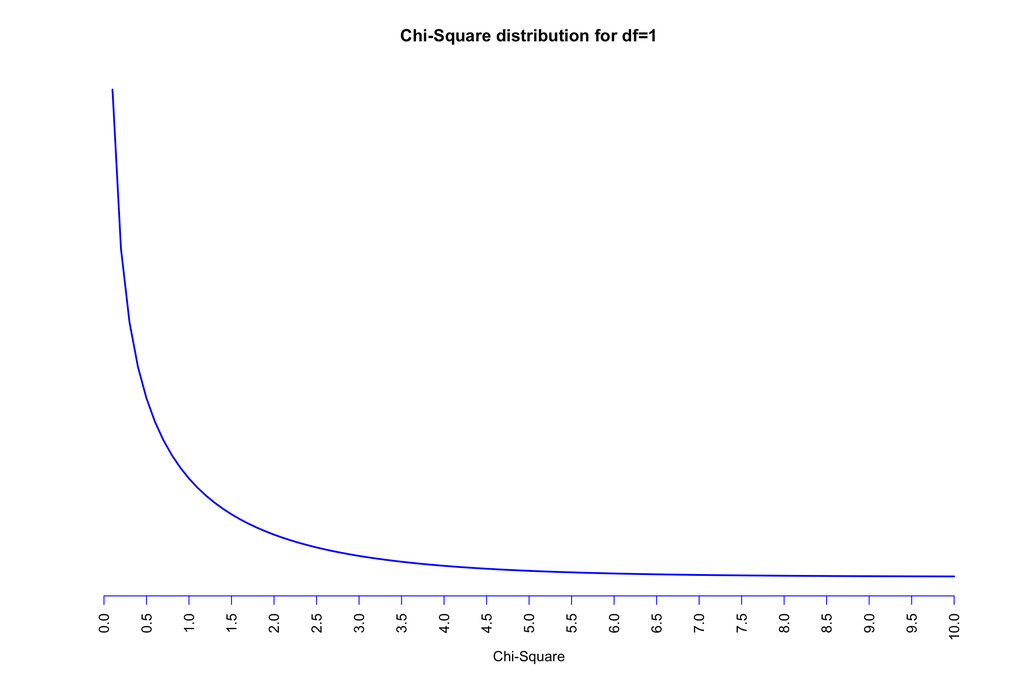

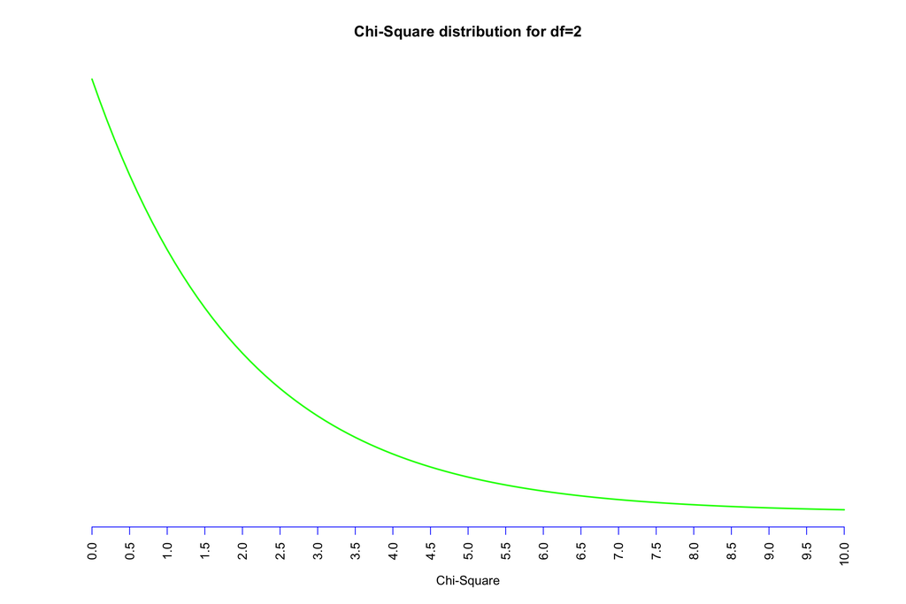

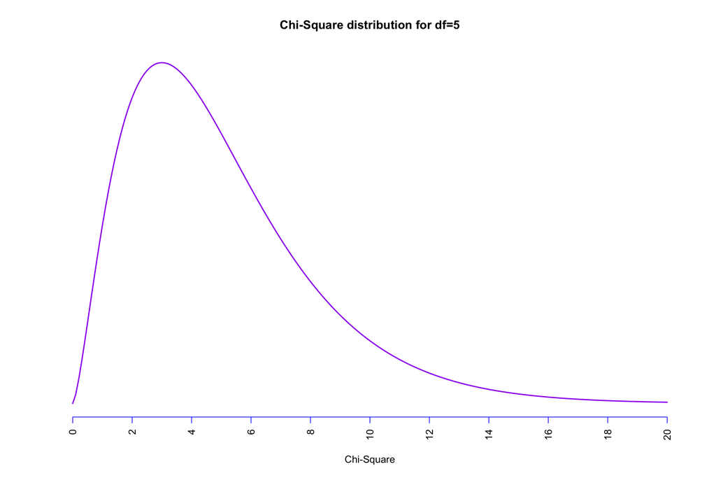

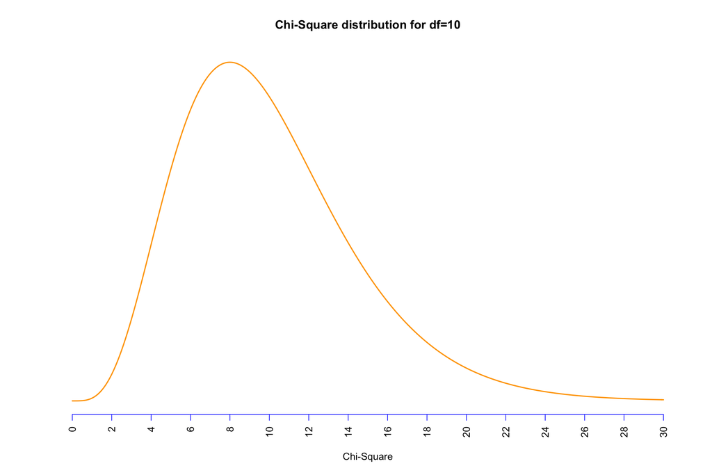

## Moving the density peak

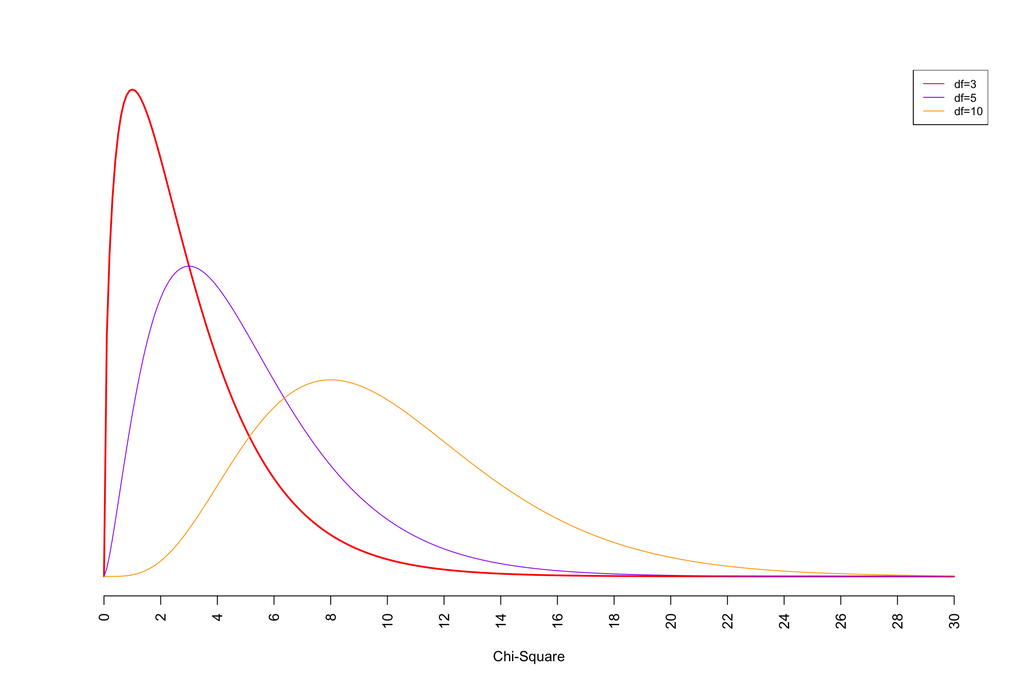

## Terug naar ons voorbeeld

We hadden $\chi^2 = \sum\frac{(f_o - f_e)^2}{f_e} = 0.44$

met $df=(R-1)(C-1) = (2-1)(2-1)=1$

## Onze verwachte $\chi^2$ verdeling

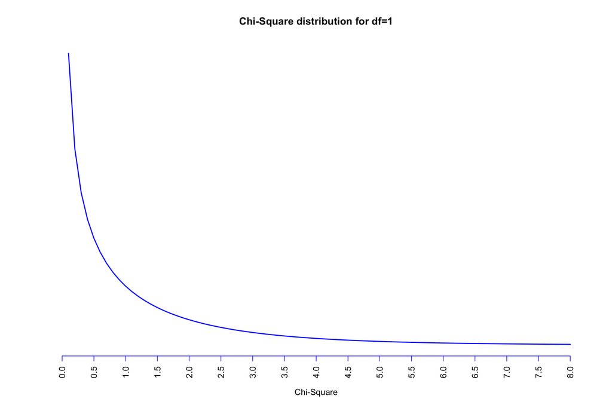

## Kritisch gebied

Tabel B.8 voor een opzoeking (blz. 659 in het boek):

- voor $\alpha=.05$
- $df=1$

De kritieke waarde van $\chi^2$ is 3.84

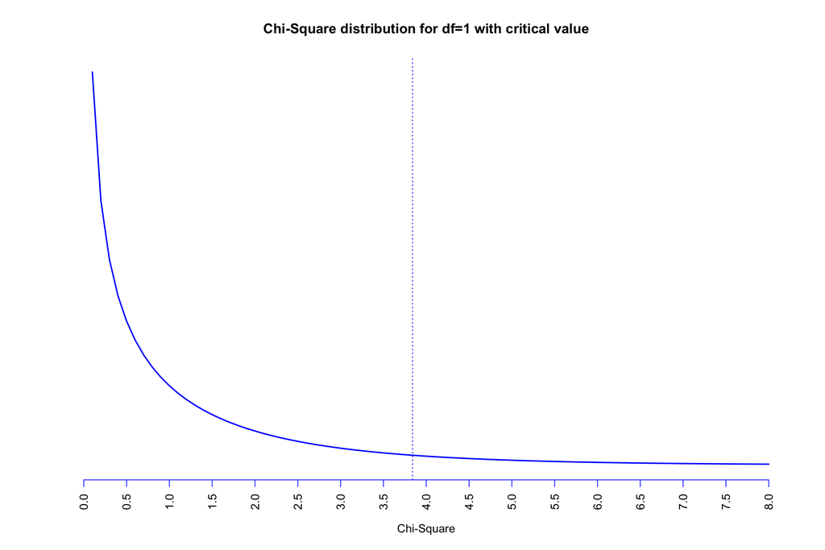

## Evaluatie

- Onze $\chi^2$ waarde is kleiner dan de kritieke waarde.
- dus kunnen we de nulhypothese van *geen verband* (onafhankelijkheid) niet verwerpen

*Er is geen bewijs dat de variabelen “extra lessen” (ja vs nee) en “examenresultaat” (geslaagd vs gezakt) samenhangen, $\chi^2(1) =0.44, p > .05$.*

Deel 3: Effectmaten voor de Chi-kwadraattoets

## Twee simpele effectgroottes

Doel: “gecorrigeerde” indicatie van het effect

(Denk aan de kwestie van steekproefgrootte voor teststatistieken)

- Phi-coëfficiënt
- Cramer’s V

## Phi

$\phi = \sqrt{\frac{\chi^2}{n}}$

Interpretatie:

- $\phi=0.10$ (klein effect)
- $\phi=0.30$ (middelmatig effect)
- $\phi=0.50$ (groot effect)

Hier: $\phi=\sqrt{\frac{0.44}{100}}=0.07$

## Cramer’s V

Als we verder gaan dan 2 bij 2 tabellen:

b.v. oogkleur (groen, blauw, bruin) bij testresultaat (geslaagd, niet geslaagd, niet geprobeerd)

$V = \sqrt{\frac{\chi^2}{n(df*)}}$, waarbij $df*$ de kleinste is van (R-1) en (C-1)

Hier geldt: $V = \sqrt{\frac{0.44}{100*1}} = 0.07$

Zie pagina 586 voor de interpretatie.

## In de live sessie

- voorbeelden van de Chi-Square test met de hand

## Recap

- categorische data komen veel voor en vormen een probleem voor onze standaard tests
- we kunnen de Chi-kwadraat toets gebruiken om te evalueren of twee variabelen geassocieerd zijn
- de Chi-kwadraat waarde drukt uit hoeveel de waargenomen gegevens afwijken van de verwachte

## Volgende week

De binomiaaltest